# ATR Analysis - ITQB

## Performing the integration

```r
# Function to perform spectral integration on DPT data (based on Leila_code_modified.Rmd)
perform_spectral_integration <- function(dpt_data) {
  cat("Starting spectral integration processing...\n")

  # Load required library for integration
  if (!require(pracma, quietly = TRUE)) {
    install.packages("pracma")
    library(pracma)
  }

  # Prepare the data in the format needed for integration
  # Rename columns to match expected format
  comb <- dpt_data %>%
    select(filename, wavenumber, snv_corrected) %>%
    dplyr::rename(sample = filename, abs = snv_corrected)

  # Define spectral windows of interest (same as Leila's code)
  red1 <- comb[comb$wavenumber > 2839 & comb$wavenumber < 2870, ]  # Aliphatic 1
  red2 <- comb[comb$wavenumber > 2898 & comb$wavenumber < 2976, ]  # Aliphatic 2
  red3 <- comb[comb$wavenumber > 1690 & comb$wavenumber < 1780, ]  # Carbonyl
  red4 <- comb[comb$wavenumber > 1580 & comb$wavenumber < 1660, ]  # Protein/amide
  red5 <- comb[comb$wavenumber > 1500 & comb$wavenumber < 1550, ]  # Complex plant
  red6 <- comb[comb$wavenumber > 900 & comb$wavenumber < 1200, ]   # Sugars

  # Get unique samples
  sample <- unique(comb$sample)

  # Create integration results data frame
  ints <- data.frame(
    sample = sample,
    int_2839_2870 = numeric(length(sample)),
    int_2898_2976 = numeric(length(sample)),
    int_1690_1780 = numeric(length(sample)),
    int_1580_1660 = numeric(length(sample)),
    int_1500_1550 = numeric(length(sample)),
    int_900_1200 = numeric(length(sample)),
    stringsAsFactors = FALSE
  )

  # Calculate integrated areas for each spectral window and sample
  cat("Processing", length(sample), "samples for integration...\n")
  for (i in seq_len(nrow(ints))) {
    current_sample <- sample[i]

    # Extract data for current sample from each spectral window
    sample_red1 <- red1[red1$sample == current_sample, ]
    sample_red2 <- red2[red2$sample == current_sample, ]
    sample_red3 <- red3[red3$sample == current_sample, ]
    sample_red4 <- red4[red4$sample == current_sample, ]
    sample_red5 <- red5[red5$sample == current_sample, ]
    sample_red6 <- red6[red6$sample == current_sample, ]

    # Calculate area under curve (integration) using trapezoidal rule
    if (nrow(sample_red1) > 1) {
      ints$int_2839_2870[i] <- pracma::trapz(sample_red1$wavenumber, sample_red1$abs)
    }

    if (nrow(sample_red2) > 1) {
      ints$int_2898_2976[i] <- pracma::trapz(sample_red2$wavenumber, sample_red2$abs)
    }

    if (nrow(sample_red3) > 1) {
      ints$int_1690_1780[i] <- pracma::trapz(sample_red3$wavenumber, sample_red3$abs)
    }

    if (nrow(sample_red4) > 1) {
      ints$int_1580_1660[i] <- pracma::trapz(sample_red4$wavenumber, sample_red4$abs)
    }

    if (nrow(sample_red5) > 1) {
      ints$int_1500_1550[i] <- pracma::trapz(sample_red5$wavenumber, sample_red5$abs)
    }

    if (nrow(sample_red6) > 1) {
      ints$int_900_1200[i] <- pracma::trapz(sample_red6$wavenumber, sample_red6$abs)
    }
  }

  # Use existing metadata from the input data (no need to re-extract)
  cat("Using existing metadata from DPT data...\n")
  basic_meta <- dpt_data %>%
    select(filename, plant, method, run_date, run_rep) %>%
    distinct() %>%
    dplyr::rename(sample = filename)

  # Combine metadata with integration results
  ftir_data <- merge(basic_meta, ints, by = "sample", all = TRUE)

  # Rename integration columns to match expected names
  names(ftir_data)[names(ftir_data) == "int_1580_1660"] <- "int_microbial"
  names(ftir_data)[names(ftir_data) == "int_1500_1550"] <- "int_complex_plant"
  names(ftir_data)[names(ftir_data) == "int_1690_1780"] <- "int_carbonyl"
  names(ftir_data)[names(ftir_data) == "int_900_1200"] <- "int_sugars"

  # Calculate derived metrics
  ftir_data$aliphatic <- ftir_data$int_2839_2870 + ftir_data$int_2898_2976
  ftir_data$total_peak_area <- ftir_data$aliphatic + ftir_data$int_microbial + ftir_data$int_complex_plant + ftir_data$int_carbonyl + ftir_data$int_sugars
  ftir_data$aliphatic_prop <- ftir_data$aliphatic / ftir_data$total_peak_area
  ftir_data$complex_plant_prop <- ftir_data$int_complex_plant / ftir_data$total_peak_area
  ftir_data$carbonyl_prop <- ftir_data$int_carbonyl / ftir_data$total_peak_area
  ftir_data$sugars_prop <- ftir_data$int_sugars / ftir_data$total_peak_area
  ftir_data$microbial_prop <- ftir_data$int_microbial / ftir_data$total_peak_area
  ftir_data$aliphatic_microbial_prop <- ftir_data$aliphatic_prop / ftir_data$microbial_prop
  ftir_data$complex_microbial_prop <- ftir_data$complex_plant_prop / ftir_data$microbial_prop
  ftir_data$total_area_no_sugars <- ftir_data$total_peak_area - ftir_data$int_sugars
  ftir_data$aliphatic_prop_no_sugars <- ftir_data$aliphatic / ftir_data$total_area_no_sugars
  ftir_data$complex_plant_prop_no_sugars <- ftir_data$int_complex_plant / ftir_data$total_area_no_sugars
  # Remove individual aliphatic integration columns (keep only derived metrics)
  ftir_data <- ftir_data %>%
    select(-int_2839_2870, -int_2898_2976)

  # Save the processed data to the output directory
  today <- format(Sys.Date(), "%Y-%m-%d")
  output_file <- file.path(outputs_folder, paste0("processed_int_data_", today, ".csv"))
  write.csv(ftir_data, file = output_file, row.names = FALSE)
  cat("Saved processed integration data to:", output_file, "\n")

  cat("Integration processing completed successfully.\n")
  return(ftir_data)
}
# Try to find the most recent processed integration data file
ftir_file <- find_most_recent_processed_file(outputs_folder)
```

```
#> Found 3 processed integration files
#> Using most recent file: processed_int_data_2026-07-29.csv
```

```r
use_cache <- FALSE

if (!is.null(ftir_file) && file.exists(ftir_file)) {
  cached_ftir_data <- read_csv(ftir_file, show_col_types = FALSE)

  # ftir_data$sample is just dpt_data$filename renamed (see basic_meta above),
  # so we can directly compare the DPT files just loaded against the files
  # already represented in the cached integration results.
  current_files <- unique(dpt_data$filename)
  cached_files  <- unique(cached_ftir_data$sample)
  new_files     <- setdiff(current_files, cached_files)

  if (length(new_files) == 0) {
    ftir_data <- cached_ftir_data
    use_cache <- TRUE
    cat("No new DPT files since cache was generated -- reusing cached integration data from:", basename(ftir_file), "\n")
    cat("Dimensions:", dim(ftir_data), "\n")
    cat("Columns:", names(ftir_data), "\n")
  } else {
    cat("Found", length(new_files), "new DPT file(s) not in the cached data:\n")
    cat(paste(" -", new_files), sep = "\n")
    cat("\nReprocessing all DPT data to include the new file(s)...\n")
  }
} else {
  cat("No processed integration data found. Processing raw DPT data to generate integration results...\n")
}
```

```
#> No new DPT files since cache was generated -- reusing cached integration data from: processed_int_data_2026-07-29.csv
#> Dimensions: 42 21
#> Columns: sample plant method run_date run_rep int_carbonyl int_microbial int_complex_plant int_sugars aliphatic total_peak_area aliphatic_prop complex_plant_prop carbonyl_prop sugars_prop microbial_prop aliphatic_microbial_prop complex_microbial_prop total_area_no_sugars aliphatic_prop_no_sugars …
```

```r
if (!use_cache) {
  # Check if we have the required dpt_data from previous chunk
  if (!exists("dpt_data") || nrow(dpt_data) == 0) {
    stop("No DPT data available for integration. Please ensure the DPT data import was successful.")
  }

  # Process raw DPT data using the integrated function
  ftir_data <- perform_spectral_integration(dpt_data)

  # Verify the processing was successful
  if (is.null(ftir_data) || nrow(ftir_data) == 0) {
    stop("Failed to process DPT data for integration.")
  }

  cat("Successfully processed", nrow(ftir_data), "samples from DPT data\n")
  cat("Generated columns:", names(ftir_data), "\n")
}
```

## Generating statistics

This code chunk calculates summary statistics (mean and standard error) for the derived metrics (aliphatic, carbonyl, protein/amide, complex plant, sugars proportions) grouped by plant, preparation method, and plant-method combinations. The results are stored in separate data frames for later visualization.

```r
# Calculate summary statistics by group
plant_stats <- ftir_data %>%
  mutate(plant = factor(plant, levels = sort(unique(plant)))) %>%
  group_by(plant) %>%
  summarise(
    Mean_aliphatic_prop = mean(aliphatic_prop, na.rm = TRUE),
    SE_aliphatic_prop = sd(aliphatic_prop, na.rm = TRUE) / sqrt(n()),
    Mean_carbonyl_prop = mean(carbonyl_prop, na.rm = TRUE),
    SE_carbonyl_prop = sd(carbonyl_prop, na.rm = TRUE) / sqrt(n()),
    Mean_microbial_prop = mean(microbial_prop, na.rm = TRUE),
    SE_microbial_prop = sd(microbial_prop, na.rm = TRUE) / sqrt(n()),
    Mean_complex_plant_prop = mean(complex_plant_prop, na.rm = TRUE),
    SE_complex_plant_prop = sd(complex_plant_prop, na.rm = TRUE) / sqrt(n()),
    Mean_sugars_prop = mean(sugars_prop, na.rm = TRUE),
    SE_sugars_prop = sd(sugars_prop, na.rm = TRUE) / sqrt(n()),
    Mean_aliphatic_prop_no_sugars = mean(aliphatic_prop_no_sugars, na.rm = TRUE),
    SE_aliphatic_prop_no_sugars = sd(aliphatic_prop_no_sugars, na.rm = TRUE) / sqrt(n()),
    Mean_carbonyl_prop_no_sugars = mean(carbonyl_prop, na.rm = TRUE),
    SE_carbonyl_prop_no_sugars = sd(carbonyl_prop, na.rm = TRUE) / sqrt(n()),
    Mean_microbial_prop_no_sugars = mean(microbial_prop, na.rm = TRUE),
    SE_microbial_prop_no_sugars = sd(microbial_prop, na.rm = TRUE) / sqrt(n()),
    Mean_complex_plant_prop_no_sugars = mean(complex_plant_prop_no_sugars, na.rm = TRUE),
    SE_complex_plant_prop_no_sugars = sd(complex_plant_prop_no_sugars, na.rm = TRUE) / sqrt(n()),
    .groups = 'drop'
  )

method_stats <- ftir_data %>%
  group_by(method) %>%
  summarise(
    Mean_aliphatic_prop = mean(aliphatic_prop, na.rm = TRUE),
    SE_aliphatic_prop = sd(aliphatic_prop, na.rm = TRUE) / sqrt(n()),
    Mean_carbonyl_prop = mean(carbonyl_prop, na.rm = TRUE),
    SE_carbonyl_prop = sd(carbonyl_prop, na.rm = TRUE) / sqrt(n()),
    Mean_microbial_prop = mean(microbial_prop, na.rm = TRUE),
    SE_microbial_prop = sd(microbial_prop, na.rm = TRUE) / sqrt(n()),
    Mean_complex_plant_prop = mean(complex_plant_prop, na.rm = TRUE),
    SE_complex_plant_prop = sd(complex_plant_prop, na.rm = TRUE) / sqrt(n()),
    Mean_sugars_prop = mean(sugars_prop, na.rm = TRUE),
    SE_sugars_prop = sd(sugars_prop, na.rm = TRUE) / sqrt(n()),
    Mean_aliphatic_prop_no_sugars = mean(aliphatic_prop_no_sugars, na.rm = TRUE),
    SE_aliphatic_prop_no_sugars = sd(aliphatic_prop_no_sugars, na.rm = TRUE) / sqrt(n()),
    Mean_carbonyl_prop_no_sugars = mean(carbonyl_prop, na.rm = TRUE),
    SE_carbonyl_prop_no_sugars = sd(carbonyl_prop, na.rm = TRUE) / sqrt(n()),
    Mean_microbial_prop_no_sugars = mean(microbial_prop, na.rm = TRUE),
    SE_microbial_prop_no_sugars = sd(microbial_prop, na.rm = TRUE) / sqrt(n()),
    Mean_complex_plant_prop_no_sugars = mean(complex_plant_prop_no_sugars, na.rm = TRUE),
    SE_complex_plant_prop_no_sugars = sd(complex_plant_prop_no_sugars, na.rm = TRUE) / sqrt(n()),
    .groups = 'drop'
  )

plant_method_stats <- ftir_data %>%
  mutate(plant = factor(plant, levels = sort(unique(plant)))) %>%
  group_by(plant, method) %>%
  summarise(
    Mean_aliphatic_prop = mean(aliphatic_prop, na.rm = TRUE),
    SE_aliphatic_prop = sd(aliphatic_prop, na.rm = TRUE) / sqrt(n()),
    Mean_carbonyl_prop = mean(carbonyl_prop, na.rm = TRUE),
    SE_carbonyl_prop = sd(carbonyl_prop, na.rm = TRUE) / sqrt(n()),
    Mean_microbial_prop = mean(microbial_prop, na.rm = TRUE),
    SE_microbial_prop = sd(microbial_prop, na.rm = TRUE) / sqrt(n()),
    Mean_complex_plant_prop = mean(complex_plant_prop, na.rm = TRUE),
    SE_complex_plant_prop = sd(complex_plant_prop, na.rm = TRUE) / sqrt(n()),
    Mean_sugars_prop = mean(sugars_prop, na.rm = TRUE),
    SE_sugars_prop = sd(sugars_prop, na.rm = TRUE) / sqrt(n()),
    Mean_aliphatic_prop_no_sugars = mean(aliphatic_prop_no_sugars, na.rm = TRUE),
    SE_aliphatic_prop_no_sugars = sd(aliphatic_prop_no_sugars, na.rm = TRUE) / sqrt(n()),
    Mean_carbonyl_prop_no_sugars = mean(carbonyl_prop, na.rm = TRUE),
    SE_carbonyl_prop_no_sugars = sd(carbonyl_prop, na.rm = TRUE) / sqrt(n()),
    Mean_microbial_prop_no_sugars = mean(microbial_prop, na.rm = TRUE),
    SE_microbial_prop_no_sugars = sd(microbial_prop, na.rm = TRUE) / sqrt(n()),
    Mean_complex_plant_prop_no_sugars = mean(complex_plant_prop_no_sugars, na.rm = TRUE),
    SE_complex_plant_prop_no_sugars = sd(complex_plant_prop_no_sugars, na.rm = TRUE) / sqrt(n()),
    .groups = 'drop'
  )
```

# Visualizing functional group proportions by method

Percentage stacked bar charts comparing preparation methods within each plant. Each bar is one method; segments are the five functional-group region proportions (aliphatic/simple plant, carbonyl, protein/amide, complex plant, sugars) from `plant_method_stats`. Colors come from `get_method_region_palette()`: each method keeps its own fixed hue (from `method_colors`/`method_hues` in the config), and region is encoded as a lightness shade within that hue, ordered so adjacent segments in the stack are never two similar shades.

```r
# Region display/stacking order -- bottom to top. This order also drives the
# color assignment in get_method_region_palette(), so change it here only.
region_order <- c("aliphatic", "carbonyl", "microbial", "complex", "sugar")
region_labels <- c(
  aliphatic = "Simple Plant",
  carbonyl  = "Carbonyl",
  microbial = "Protein/amide",
  complex   = "Complex Plant",
  sugar     = "Sugars"
)

# Lightness assigned to each region -- the SAME values used to build the fill
# colors (get_method_region_palette()) and the grayscale key (build_region_key()).
# Reused below to pick label text color, so labels always match the key's logic
# even if region_order or method_region_L_range change.
region_lightness <- get_region_lightness(region_order)


# Methods to leave out of the functional-group bar charts entirely: the
# h2o/naoh trial washes, unmilled "raw", and both suberin precipitate
# fractions. The precipitates are extract chemistry rather than root
# residue, so integrating them under these 5 root-derived windows wouldn't
# be a meaningful comparison.
# Defined ONCE here and reused below in the combined (all-plant) figure too --
# previously the combined figure computed its method list straight from
# plant_method_stats with no exclusion filter at all, so a method dropped
# from every individual per-plant chart could still have leaked back into
# the combined one. Sharing this single vector between both makes that
# impossible: whichever methods change here update both figures identically.
excluded_bar_methods <- c("h2o20", "h2o30", "naoh20", "naoh30", "raw",
                           "suberin-precipitate", "suberin-dark-precipitate")

# Builds one plant's % stacked bar chart, one bar per method.
build_method_region_bar_plot <- function(stats_data, current_plant, title = NULL) {
  plant_data <- stats_data %>%
    filter(plant == current_plant) %>%
    filter(!method %in% excluded_bar_methods)


  present_methods <- sort(unique(plant_data$method))

  if (is.null(title)) {
    title <- str_to_title(current_plant)
  }

  long_data <- plant_data %>%
    select(method,
           aliphatic = Mean_aliphatic_prop,
           carbonyl  = Mean_carbonyl_prop,
           microbial = Mean_microbial_prop,
           complex   = Mean_complex_plant_prop,
           sugar     = Mean_sugars_prop) %>%
    pivot_longer(cols = -method, names_to = "region", values_to = "prop") %>%
    mutate(
      region   = factor(region, levels = region_order),
      method   = factor(method, levels = present_methods),
      pct      = prop * 100,
      fill_key = paste(method, region, sep = "_"),
      text_color = ifelse(region_lightness[as.character(region)] > text_color_L_threshold, "black", "white")
    )

  region_palette <- get_method_region_palette(regions = region_order, methods = present_methods)

  ggplot(long_data, aes(x = method, y = prop, fill = fill_key, group = region)) +
    geom_col(position = position_stack(reverse = TRUE),
             linewidth = 0.00, width = 0.88) +
    geom_text(aes(label = paste0(round(pct, 1), "%")),
              position = position_stack(reverse = TRUE, vjust = 0.5),
              color = long_data$text_color,
              size = 3.6, fontface = "bold") +
    scale_fill_manual(values = region_palette) +
    scale_y_continuous(labels = scales::percent_format(accuracy = 1),
                       expand = expansion(mult = c(0.01, 0.02))) +
    guides(fill = "none") +
    labs(x = NULL, y = "Functional Group Proportion (%)", title = title) +
    theme(axis.text.x = element_text(angle = 45, hjust = 1),
          plot.title = element_text(hjust = 0.5, size = 15, face = "bold"),
          legend.position = "none")
}
```

Because region is encoded only as lightness (not hue), one grayscale key explains the shading for every method/plant panel – there’s no need for a separate legend per panel.

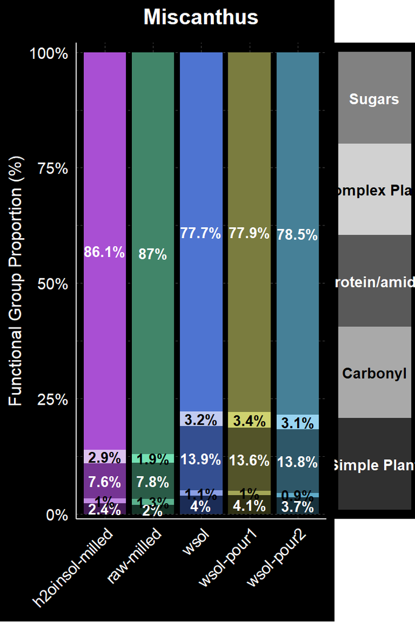

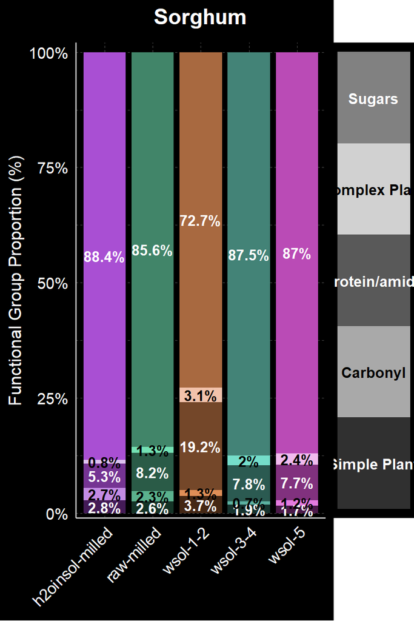

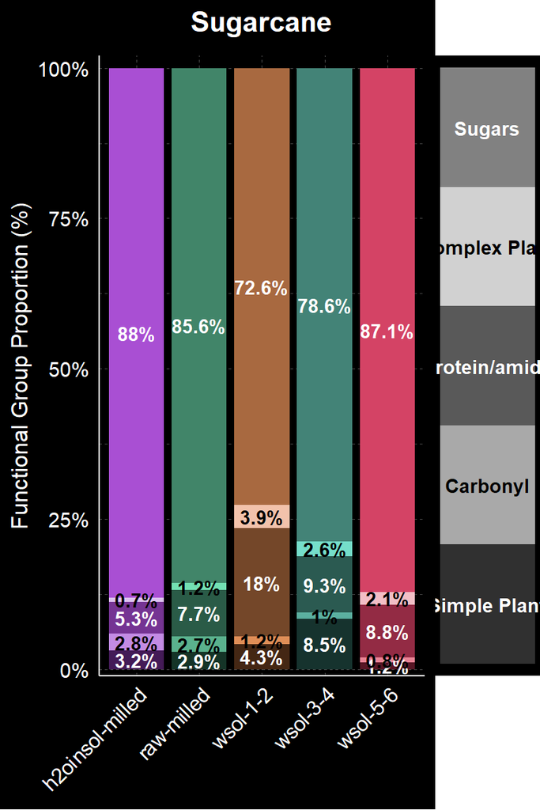

```r
plants_for_bar <- sort(unique(plant_method_stats$plant))

region_key_plot <- build_region_key(region_order, region_labels)

bar_plots <- lapply(plants_for_bar, function(pt) {
  build_method_region_bar_plot(plant_method_stats, pt)
})
names(bar_plots) <- plants_for_bar

for (pt in plants_for_bar) {
  pt_plot_with_key <- cowplot::plot_grid(
    bar_plots[[pt]], region_key_plot,
    nrow = 1,
    align = "h", axis = "tb",  # lines up the key's y-axis with the bar plot's y-axis
    rel_widths = c(1, 0.24)    # same idea as the combined figure's rel_widths, just for 1 plant instead of N
  )

  print(pt_plot_with_key)
  ggsave_themed(paste0("method_region_stackedbar_", pt, ".png"),
                pt_plot_with_key, width = 7.3, height = 6, dpi = 300)
}
```